# Linear Classifier

How to classify various data points into two types ( for example : spam/non spam emails):

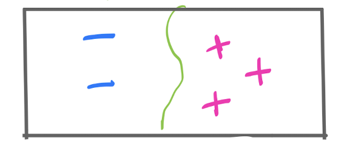

**Fig1: Binary Classifier**

How to identify equation of a classifier (straight line in 2D plane) which can split this data sets in two groups?

**A quick detour with Vector Algebra :**

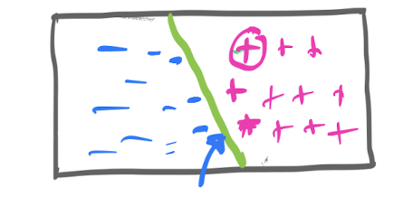

**Fig2. Line classifier useful in 2D**

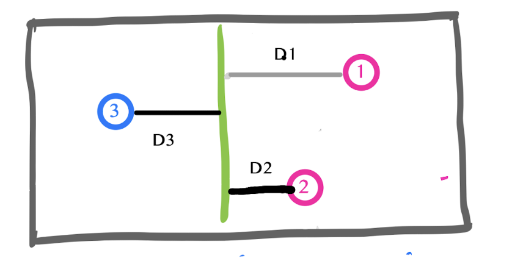

**Fig 3. Distance as aid for classifier**

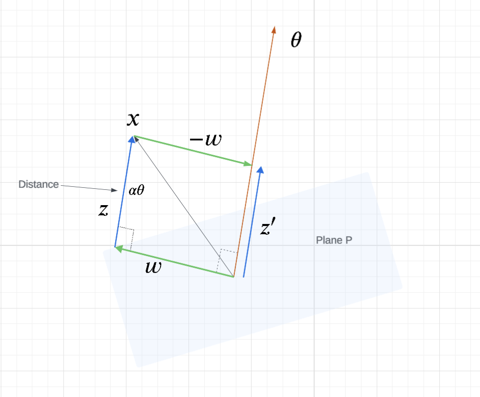

**Fig4 Orthogonal Projection**

Let’s assume the plane P is the hyperplane which will be used to classify two groups of data. x is any vector. Distance between point x and the hyperplane is given by $\alpha\theta$. Why? Theta is the Perpendicular to the plane. So the vector to point x is given by $\alpha\theta$

We need to find this $\alpha\theta$. By vector geometry :

$$w+z=x$$

Equation of the plane is given by $\theta.x=0$ where x is given by:

$$x= \begin{bmatrix}
x_1 \\
x_2 \\
x_3 \\
....\\
x_n
\end{bmatrix} \tag{0}$$

### 0.1 Algorithm: Perceptron

Binary classification : Data represented by two labels.

Assume we have a data set as per the table. So we have a feature matrix :

$$Feature = \quad
\begin{bmatrix}
x_{11} && x_{12} && x_{13} \\
x_{21} && x_{22} && x_{23} \\
x_{31} && x_{32} && x_{33} \\
x_{41} && x_{42} && x_{43} \\
x_{51} && x_{52} && x_{53} \\
\end{bmatrix}
\quad \quad Label \quad y=\begin{bmatrix}
1 \\
1 \\
-1 \\
-1 \\
-1 \\
\end{bmatrix}$$

Date Table

[output not shown]

**NotePseudocode**

**Perceptron (click to view code)**

```python
import numpy as np

def perceptron_single_step_update(feature_vector, label, current_theta, current_theta_0):
    decision = label * (np.dot(current_theta, feature_vector) + current_theta_0)
    if decision <= 0:
        current_theta  = current_theta  + label * feature_vector
        current_theta_0 = current_theta_0 + label
    return current_theta, current_theta_0

def perceptron(feature_matrix, labels, T):
    theta   = np.zeros(feature_matrix.shape[1])
    theta_0 = 0
    nsamples = feature_matrix.shape[0]
    for t in range(T):
        for i in get_order(nsamples):
            theta, theta_0 = perceptron_single_step_update(
                feature_matrix[i], labels[i], theta, theta_0)
    return theta, theta_0
```

### 0.2 Large Margin Classifier

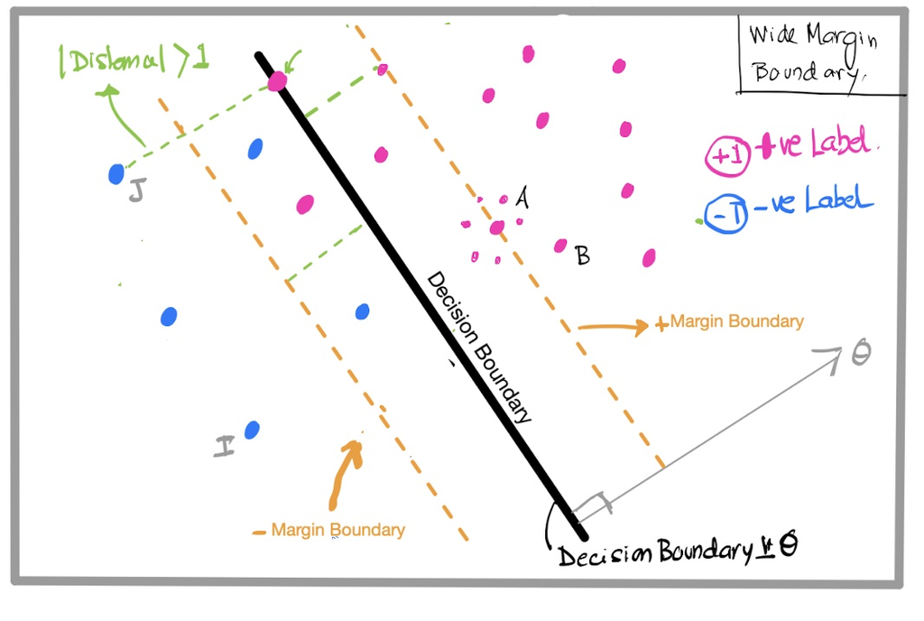

Fig8: Wide margin classifier

The decision boundary equation is given by:

$$\theta^T.x +\theta_0 = 0 \tag{4}$$

The two margins are given by :

$$\theta^T.x +\theta_0 = -1 \tag{5}$$

$$\theta^T.x +\theta_0 = +1 \tag{6}$$

The distance between this two margins are given by :

$$D=\frac{2}{\theta}\tag {7}$$

[figure not shown]

[figure not shown]

#### 0.2.1 Underfitting vs Overfitting:

During Training all images are not perfectly classified.

[figure not shown]

Fig 9 : Underfitting vs Overfitting

### 0.3 Optimizing Perceptron :

What makes a classifier good classifier: When its able to split into two groups properly. That means for a proper classified group we can have an wide margin. How do we make it a wide margin? by changing the parameter. We can change the magnitude of theta to change the width of the margin:

Let’s create a new theta by dividing the current theta:

$\theta^{'}=\theta/c$

from 4:

$$\theta^T.x +\theta_0 = 0 \tag{4}$$

Dividing both sides by c

$$\frac{\theta^T.x}{c} +\frac{\theta_0}{c} = 0 \tag{5}$$

$$\theta^{'T}.x +\theta_0^{'} = 0\tag{6}$$

The equation of the classifier is still valid. For the margin equations:

$$\theta^{'T}.x +\theta_0{'} = \frac{-1}{c} \tag{7}$$

$$\theta^{'T}.x +\theta_0^{'} = \frac{1}{c} \tag{8}$$

Distance between these two lines is

$$d'=\frac{2c}{\theta} \approx \frac{\lambda}{\theta}\tag{9}$$

#### 0.3.1 Regularization

The goal is to regulate the model. This creates a wide margin and underfitting. We can increase the margin by regulating $\lambda$

The distance on one side is $\frac{1}{||\theta||}$. The distance is maximized at $\frac{1}{||\theta||^2}$

#### 0.3.2 Loss Function:

This is the Loss when the model is over fitted during training and then it misses classification points during testing.How is this loss function calculated. we will penalize the model by assigning a loss value ( a number) so that we can nudge towards our intended solution.

[figure not shown]

Fig 10 : Loss Function

$$Loss_h = g(y_{i}*(\theta.x_i))\tag{10}$$

#### 0.3.3 Optimizing Function

$$J=Loss_h + \frac{1}{||\theta||^2} \tag{12}$$

$$J=\sum_1^n g(y_i(\theta.x_i)) + \frac{1}{||\theta||^2} \tag{13}$$

$$J=\frac{1}{n}\sum_1^n g(y_i(\theta.x_i+\theta_0)) + \frac{1}{||\theta||^2} \tag{14}$$

**TipOptimizing Function**

J= Average Loss + Regularization

#### 0.3.5 Stochastic Gradient

#### 0.3.6 Support Vector

#### 0.3.7 Perceptron Performance

M times the update has been made. We know that the update formula is : $\theta_i = \theta_{i-1} + y_i.x_i$ $x_i$ = feature vector at ith round Let $t_i$ be the times when the weights are updated. $t_i \in [ 1,.....M]\in [1....T]$ to simplify two weights updates will be indicated by $w_{k+1}$ , and previous one will be indicated by $w_k$

**Total Update** is Sum of Update at every step:

[output not shown]